%%markdown

# Lombardia: One Patch, Twelve Dates

Follow Sentinel-2 patch 1208 in Lombardia3 through 2019: RGB images, differences, spectral distances, paired-pixel correlation, and a trajectory. [Open in Colab](https://colab.research.google.com/github/jfemiani/cse620b-public/blob/main/Lessons/09-Change-Detection-and-Accuracy-Assessment/demo-lombardia.ipynb). Install rasterio in a fresh Colab runtime with `%pip install rasterio`.

Source: Gallo et al., Sentinel-2 Image Time Series for Crop Mapping, https://www.kaggle.com/datasets/ignazio/sentinel2-crop-mapping (CC0). The author's RGB exporter uses stored channels 3, 2, 1 and scale 0.0001: https://github.com/mattiagatti/sits-crop-segmentation-models/blob/main/misc/export_samples_rgb.py We use the confirmed red channel, not an assumed NIR channel. Nodata is masked; these nine-band chips provide no separate cloud-quality band. These are observations of agricultural appearance, without dated disturbance labels.

%%markdown

## Follow the same fields through the year

Every panel uses the same RGB stretch. Each chip covers 480 by 480 metres on a 10 m grid; some original Sentinel-2 channels have coarser native resolution. Trace one field's appearance across dates. Inspect haze and cloud contamination alongside agricultural variation before selecting a pair for comparison.

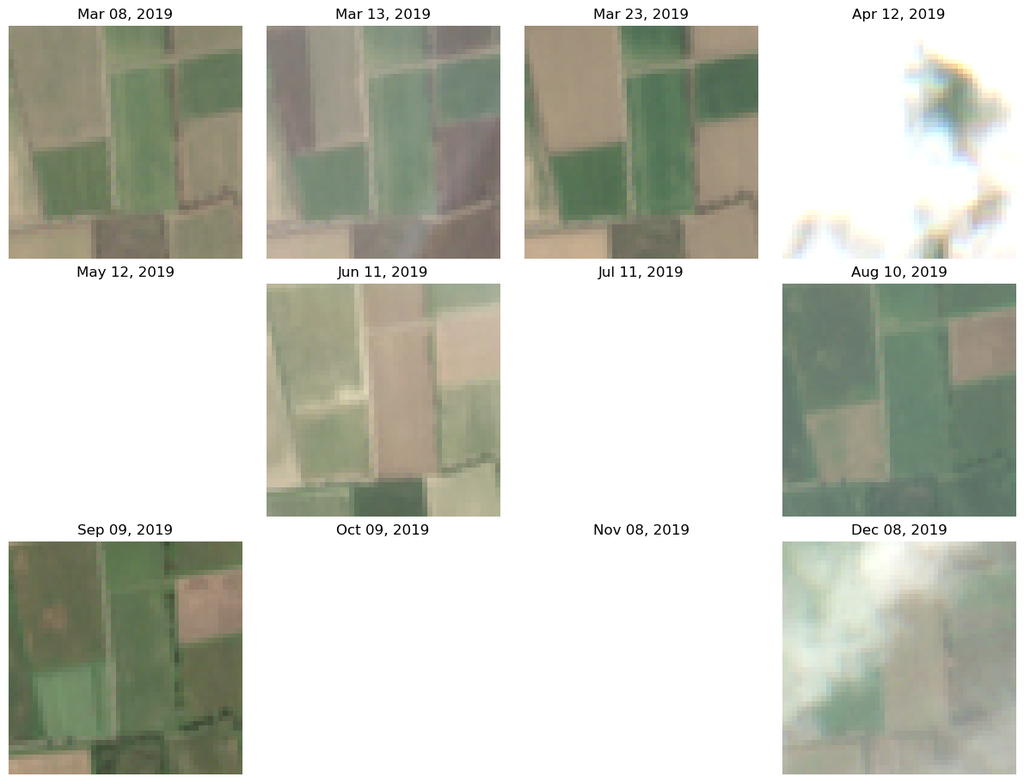

```python
fig, axes = plt.subplots(3, 4, figsize=(12, 9), layout="constrained")
for axis, date, frame in zip(axes.flat, dates, rgb):
    axis.imshow(frame)
    axis.set_title(datetime.strptime(date, "%Y%m%d").strftime("%b %d, %Y"))
    axis.axis("off")
fig.savefig(output_dir / "lombardia-sequence.png", dpi=150)
plt.show()
frames = [Image.fromarray(np.uint8(frame * 255)).resize((480, 480)) for frame in rgb]
frames[0].save(output_dir / "lombardia-flicker.gif", save_all=True,
               append_images=frames[1:], duration=700, loop=0)
```

%%markdown

## Two dates: signed differences and multiband distances

March 13 minus March 8. The red difference uses symmetric limits around zero; blue means decrease and red means increase. The two RGB views share a stretch. Magnitude combines all nine stored channels. Spectral angle compares their proportions. These summarize measured differences; interpret causes using imagery.

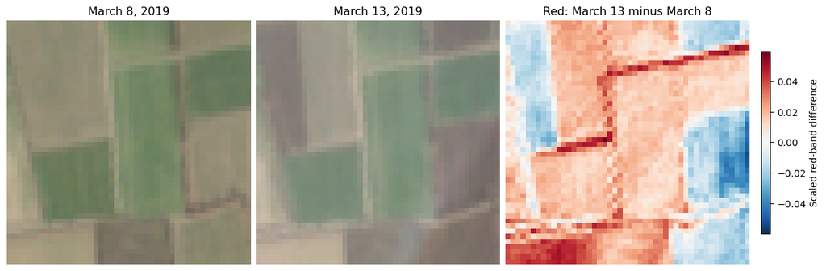

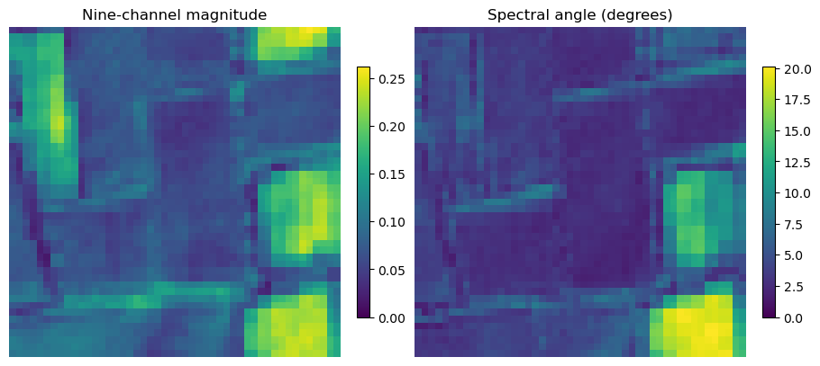

```python
before, after = images[:2]
common = np.isfinite(before).all(axis=0) & np.isfinite(after).all(axis=0)
red_difference = np.where(common, after[2] - before[2], np.nan)
magnitude = np.where(common, np.linalg.norm(after - before, axis=0), np.nan)
norm_product = np.linalg.norm(before, axis=0) * np.linalg.norm(after, axis=0)
cosine = np.divide((before * after).sum(axis=0), norm_product,
                   out=np.full(common.shape, np.nan), where=common & (norm_product > 0))
angle = np.degrees(np.arccos(np.clip(cosine, -1, 1)))
limit = np.nanmax(np.abs(red_difference))
fig, axes = plt.subplots(1, 3, figsize=(12, 4), layout="constrained")
axes[0].imshow(rgb[0])
axes[0].set_title("March 8, 2019")
axes[1].imshow(rgb[1])
axes[1].set_title("March 13, 2019")
panel = axes[2].imshow(red_difference, cmap="RdBu_r", vmin=-limit, vmax=limit)
axes[2].set_title("Red: March 13 minus March 8")
fig.colorbar(panel, ax=axes[2], shrink=0.7, label="Scaled red-band difference")
for axis in axes:
    axis.axis("off")
fig.savefig(output_dir / "lombardia-difference.png", dpi=150)
plt.show()
fig, axes = plt.subplots(1, 2, figsize=(9, 4), layout="constrained")
for axis, values, title in zip(axes, (magnitude, angle),
                               ("Nine-channel magnitude", "Spectral angle (degrees)")):
    panel = axis.imshow(values, cmap="viridis", vmin=0)
    axis.set_title(title)
    axis.axis("off")
    fig.colorbar(panel, ax=axis, shrink=0.75)
fig.savefig(output_dir / "lombardia-cva.png", dpi=150)
plt.show()
```

%%markdown

## Paired pixels, trend line, and cross-correlation

Each point is one valid location's red value on the two dates. Pearson r, slope, and intercept summarize this patch as one analysis region. The dashed identity line marks equal values. This is the book's regional calculation, repeated on the same patch used for the images and differences above.

```
r=0.742579; slope=0.852399; intercept=0.021511
```

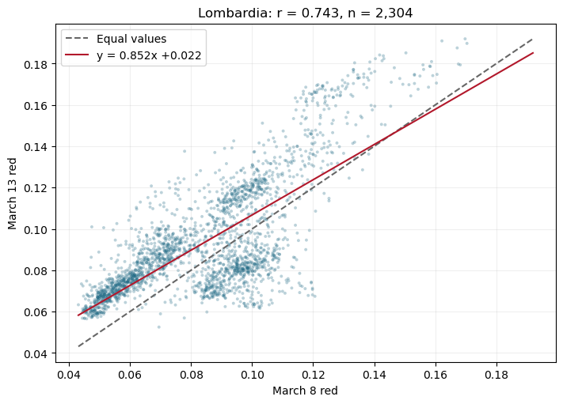

```python
first = before[2][common]
second = after[2][common]
correlation = np.corrcoef(first, second)[0, 1]
slope, intercept = np.polyfit(first, second, 1)
line_values = np.linspace(min(first.min(), second.min()), max(first.max(), second.max()), 100)
fig, axis = plt.subplots(figsize=(7, 5), layout="constrained")
axis.scatter(first, second, s=8, alpha=0.3, edgecolors="none", color="#216b86")
axis.plot(line_values, line_values, "--", color="#666666", label="Equal values")
axis.plot(line_values, slope * line_values + intercept, color="#b2182b",
          label=f"y = {slope:.3f}x {intercept:+.3f}")
axis.set(xlabel="March 8 red", ylabel="March 13 red",
         title=f"Lombardia: r = {correlation:.3f}, n = {first.size:,}")
axis.legend()
axis.grid(alpha=0.2)
fig.savefig(output_dir / "lombardia-correlation.png", dpi=150)
print(f"r={correlation:.6f}; slope={slope:.6f}; intercept={intercept:.6f}")
plt.show()
```

%%markdown

## From an image sequence to a trajectory

Track the median red value of the marked 12 by 12 pixel window across actual acquisition dates. The same window is used every time. The curve summarizes appearance through the year; RGB images help interpret vegetation, soil, and atmospheric contributions. For this teaching crop, visual RGB inspection excludes April 12, May 12, July 11, October 9, November 8, and December 8 because clouds/haze obscure the window. This manual selection is explicit; a production analysis should use a documented quality mask. Gaps remain visible.

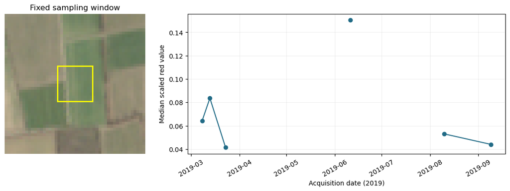

```python
times = [datetime.strptime(date, "%Y%m%d") for date in dates]
trajectory = np.nanmedian(images[:, 2, 18:30, 18:30], axis=(1, 2))
excluded_dates = {"20190412", "20190512", "20190711", "20191009", "20191108", "20191208"}
trajectory[np.array([date in excluded_dates for date in dates])] = np.nan
fig, axes = plt.subplots(1, 2, figsize=(11, 4), layout="constrained",
                         gridspec_kw={"width_ratios": [1, 2]})
axes[0].imshow(rgb[0])
axes[0].add_patch(plt.Rectangle((17.5, 17.5), 12, 12, fill=False, edgecolor="yellow", linewidth=2))
axes[0].set_title("Fixed sampling window")
axes[0].axis("off")
axes[1].plot(times, trajectory, "o-", color="#216b86")
axes[1].set(ylabel="Median scaled red value", xlabel="Acquisition date (2019)")
axes[1].tick_params(axis="x", rotation=30)
axes[1].grid(alpha=0.2)
fig.savefig(output_dir / "lombardia-trajectory.png", dpi=150)
plt.show()
```